# MECP2 Data Analysis

- This document provides an overview of the extracted features from neural networks recorded using micro-electrode arrays (MEA) in wild-type (WT) and MECP2-defcieitn (HT, KO) mice.
- The current implementation provides summary statistics for 1209 batch
- The current spike statistics are obtained from Manuel’s algorithm in his Rich Club Topology Paper
  - threshold of 5 x SD

Spike detection and spike anlaysis were performed in Matlab. `R` will be used to perform statsitsical analysis

Load 1209 data set (In `R` we call them dataframes)

```r
# matFile <- readMat('/media/timothysit/Seagate Expansion Drive/The_Mecp2_Project/feature_extraction/matlab/data/1209/featMatrix.mat')

# if on windows
matFile <- readMat('D:/The_Mecp2_Project/feature_extraction/matlab/data/1209again/featMatrix/featMatrixM5.mat')

# TODO: find way to simplify this
df1209 <- as.data.frame(matFile$featMatrix)
df1209 <- t(df1209)
df1209 <- as.data.frame(df1209)

# unlist everything in the dataframe
df1209 = as.data.frame(lapply(df1209, unlist))

# Cite this in the paper / methods section
# Henrik Bengtsson (2016). R.matlab: Read and Write MAT Files and Call MATLAB from Within R. R package version 3.6.0-9000. https://github.com/HenrikBengtsson/R.matlab

# add effective rank to the data frame
# if on windows
effRankFile <- readMat('D:/The_Mecp2_Project/feature_extraction/matlab/data/1209again/featMatrix/effRankM5.mat')
effRank <- unlist(effRankFile)

df1209$effRankCov <- effRank
```

Let’s load the 2309 dataframe as well

```r
# if on windows
matFile2309 <- readMat('D:/The_Mecp2_Project/feature_extraction/matlab/data/2309/featMatrix/featMatrixM5.mat')

df2309 <- as.data.frame(matFile2309$featMatrix)
df2309 <- t(df2309)
df2309 <- as.data.frame(df2309)
df2309 = as.data.frame(lapply(df2309, unlist))
```

We then merge the two dataframes

```r
df <- rbind(df1209, df2309)
```

Let’s begin with a preview of the data

```r
head(df)
```

```
##        batch          ID DIV genotype aveFireRate totalBurstCount
## 1.1 12_09_17 12_09_17-3A  14       HT   0.3736111               0
## 1.2 12_09_17 12_09_17-3A  22       HT   0.6541667               3
## 1.3 12_09_17 12_09_17-3A  28       HT   0.3888889               0
## 1.4 12_09_17 12_09_17-3A  35       HT   0.7416667               0
## 1.5 12_09_17 12_09_17-3A  42       HT   0.4388889               0
## 1.6 12_09_17 12_09_17-3A  49       HT   0.5930556               3
##     totalAveBurstSpikeNum    totalReg effRankCov
## 1.1                   NaN         NaN   52.14387
## 1.2                    20 -0.75140880   28.26977
## 1.3                   NaN         NaN   51.76948
## 1.4                   NaN  0.09791845   55.92442
## 1.5                   NaN -0.01229785   50.36599
## 1.6                    12 -0.29258737   36.30183
```

What is the distribution of genotypes?

- note that this includes all recording throughout development
- eg. the 6 recordings of WT are all from the same MEA

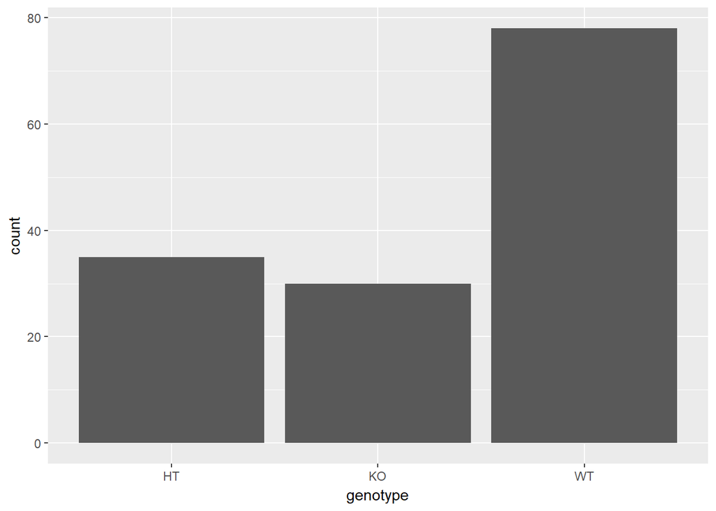

```r
ggplot(data = df) +
  geom_bar(mapping = aes(x = genotype))
```

# Spike Statistics

First let’s ask the question: do we see any trends in spike firing rate over development?

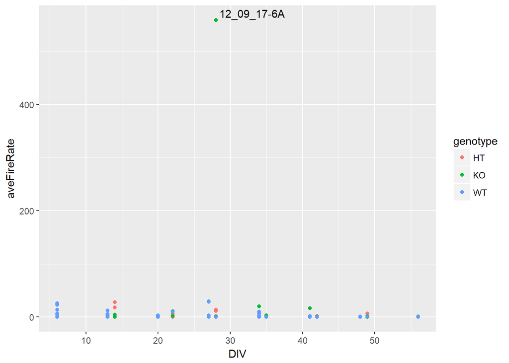

```r
ggplot(data = df) +
  geom_point(mapping = aes(x = DIV, y = aveFireRate, color = genotype)) +
  geom_text_repel(data = subset(df, aveFireRate > 200), aes(DIV, aveFireRate, label = ID))
```

We notice that there is an outlier, let’s look at the overall activity without it.

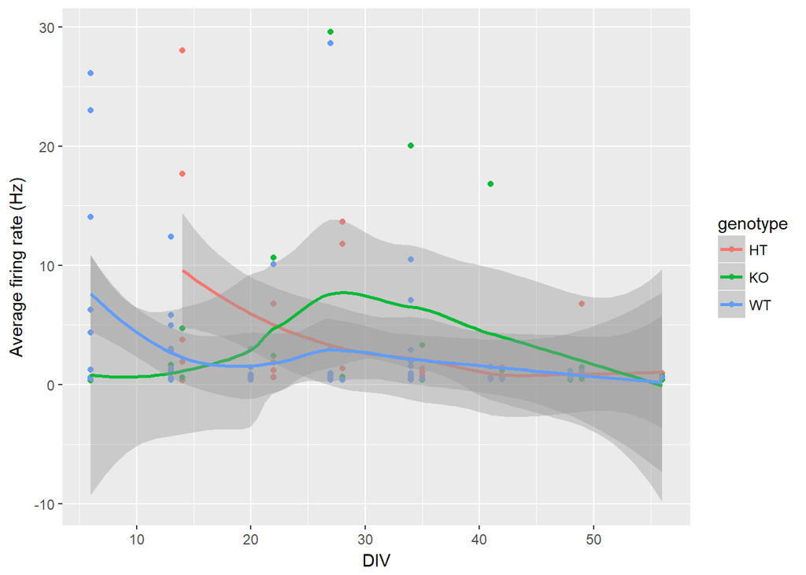

```r
ddf <- df[!(df$aveFireRate > 100),]
ggplot(data = ddf) +
  geom_point(mapping = aes(x = DIV, y = aveFireRate, color = genotype)) +
  geom_smooth(mapping = aes(x = DIV, y = aveFireRate, color = genotype)) +
  ylab('Average firing rate (Hz)')
```

- Firing rate does not change much over time, or perhaps show a slight decrease
- Firing rate amongst the three genotypes seem quite similar over time

# Bursting activity

We first look at how many of our neural networks showed bursting activtiy:

- bursting activity calculate using the gamma distribution method (Used by Eglen)
- this calculates the bursting activity of each electrode independently
- total burst count is the sum of the number of bursts observed in all electrodes

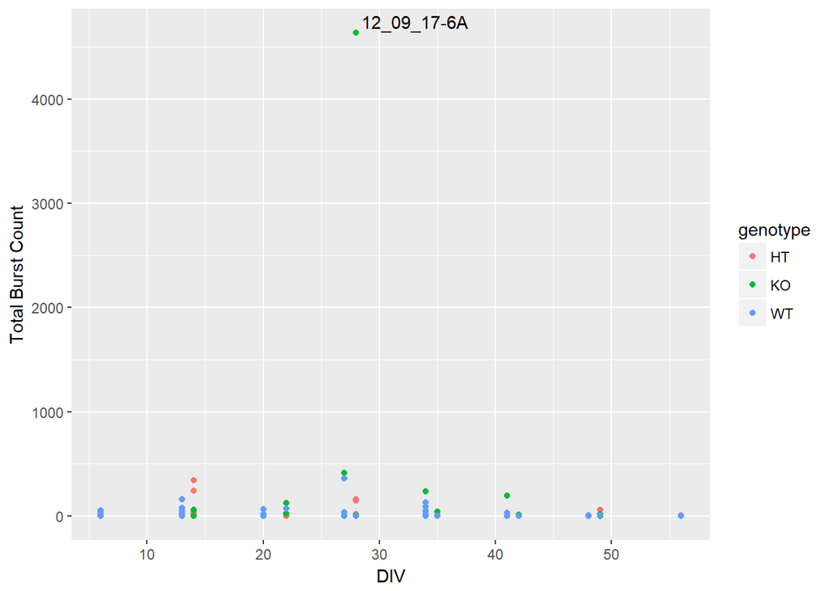

```r
ggplot(data = df) +
  geom_point(mapping = aes(x = DIV, y = totalBurstCount, color = genotype)) +
  ylab('Total Burst Count') +
  geom_text_repel(data = subset(df, totalBurstCount > 1000), aes(DIV, totalBurstCount, label = ID))
```

Again we see outlier 1209-6A, the same outlier for average firing rate. There may be positive correlation between fire rate and burst rate. We will consider that later, but for now let’s see if we can find any patterns in bursting activity by removing the outlier.

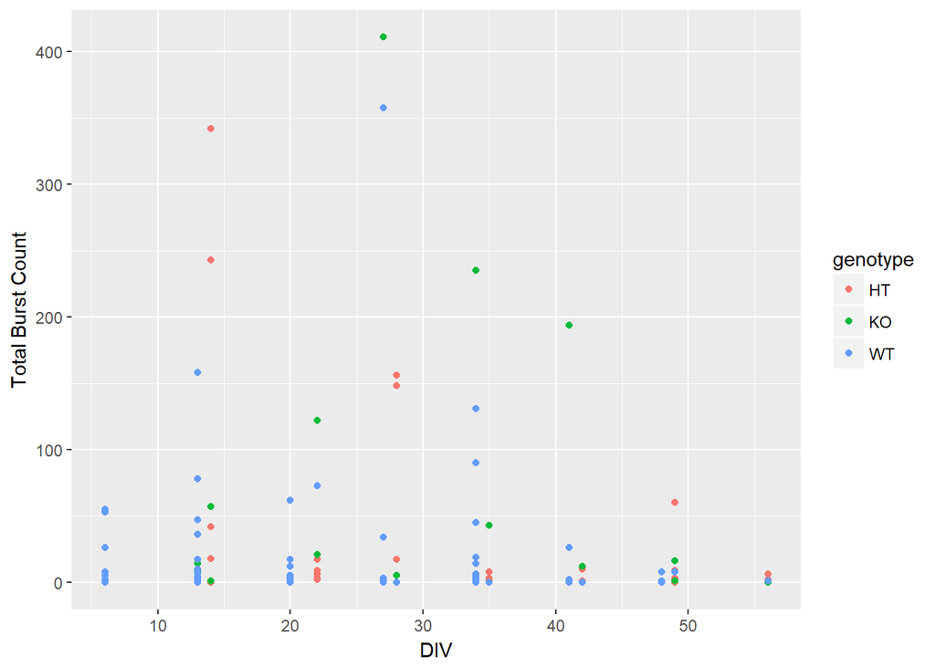

```r
ggplot(data = subset(df, totalBurstCount < 1000)) +
  geom_point(mapping = aes(x = DIV, y = totalBurstCount, color = genotype)) +
  ylab('Total Burst Count')
```

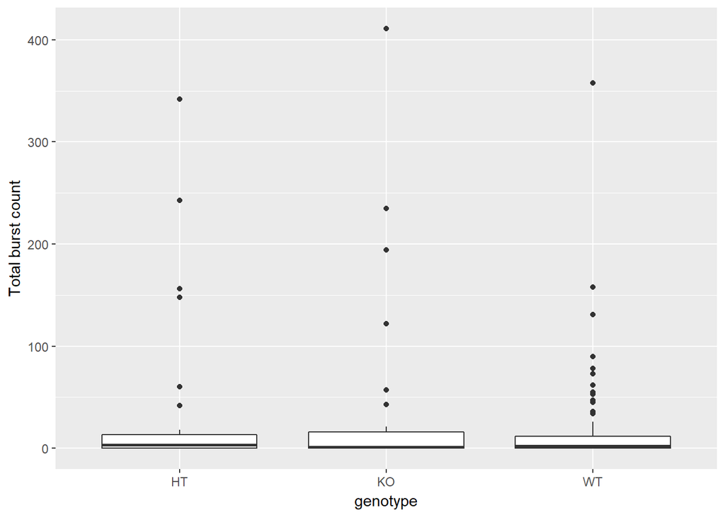

```r
# Are there any difference in bursting activity of the three genotypes?

ggplot(data = subset(df, totalBurstCount < 1000)) +
  geom_boxplot(mapping = aes(genotype, totalBurstCount)) +
  ylab('Total burst count')
```

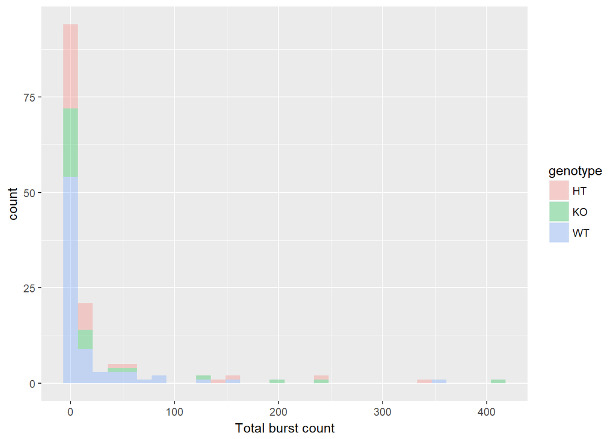

```r
# look more specifically at their distribution

ggplot(data = subset(df, totalBurstCount < 1000)) +
  geom_histogram(mapping = aes(x = totalBurstCount, fill = genotype), alpha = 0.3) +
  xlab('Total burst count')
```

- most MEAs exhibit not bursting activity regardless of genotype
- may be useful to look at the proportion of burst / no-bursting activity for each genotype

# Firing Reguality

- Regularity calculation based on Eglen and Prez
- Here I consider each electrode independently and calculate their firing regularity
- I then take the mean of all regularity values in the electrode array to get the ‘total regualrity’
- Note that there are some electrodes, and thus MEA, where this calculation is not possible, most likely because it is impossible to fit it to a gamma distribution

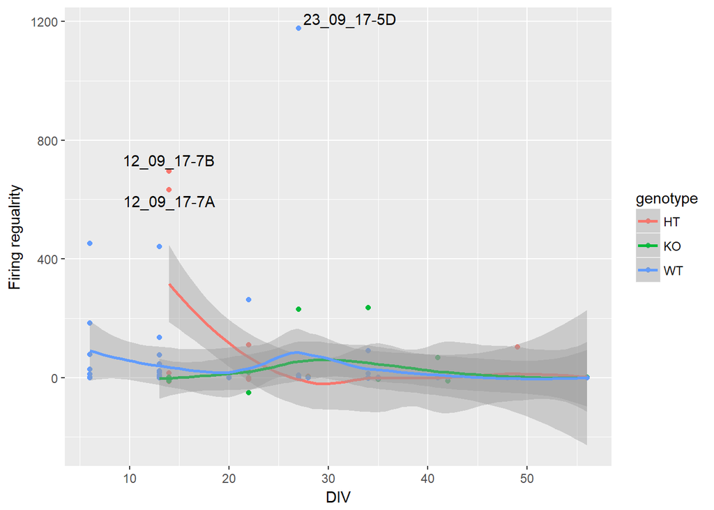

```r
# Does firing regualrity change with neural network development?

ggplot(data = subset(df, is.finite(totalReg))) +
  geom_point(mapping = aes(x = DIV, y = totalReg, color = genotype)) +
  geom_smooth(mapping = aes(x = DIV, y = totalReg, color = genotype)) +
  ylab('Firing regualrity') +
  geom_text_repel(data = subset(df, totalReg > 500 & is.finite(totalReg)), aes(x = DIV, y = totalReg, label=ID))
```

Thoughts:

- it appears that all three genotypes converge to a regualrity value of 0 over development
- there are two particular outliers in the HT group
- (possible) high regularity value at start of development for HT and WT group, but number of samples too small to draw any conclusions

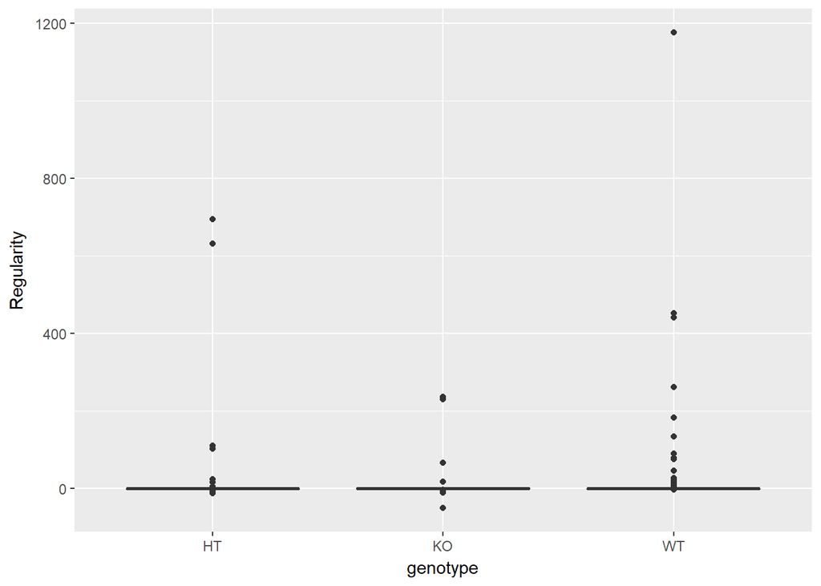

```r
ggplot(data = subset(df, is.finite(totalReg))) +
  geom_boxplot(mapping = aes(genotype, totalReg)) +
  ylab('Regularity')
```

# Effective Rank

## Does effective rank change through development?

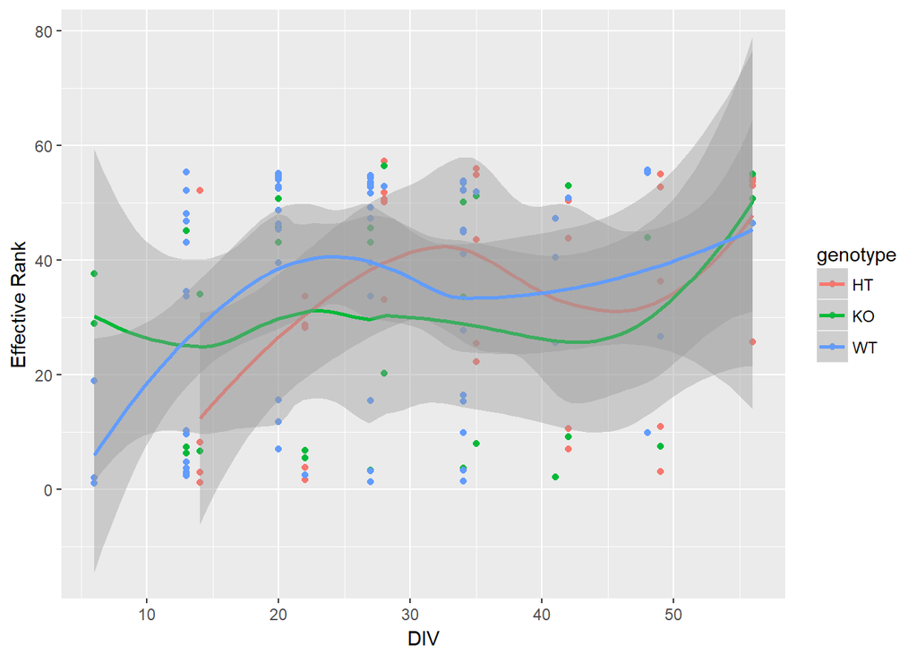

```r
ggplot(data = subset(df, is.finite(effRankCov))) +
  geom_point(mapping = aes(x = DIV, y = effRankCov, color = genotype)) +
  geom_smooth(mapping = aes(x = DIV, y = effRankCov, color = genotype)) +
  ylab('Effective Rank')
```

## Is there a difference in effective rank between genotypes?

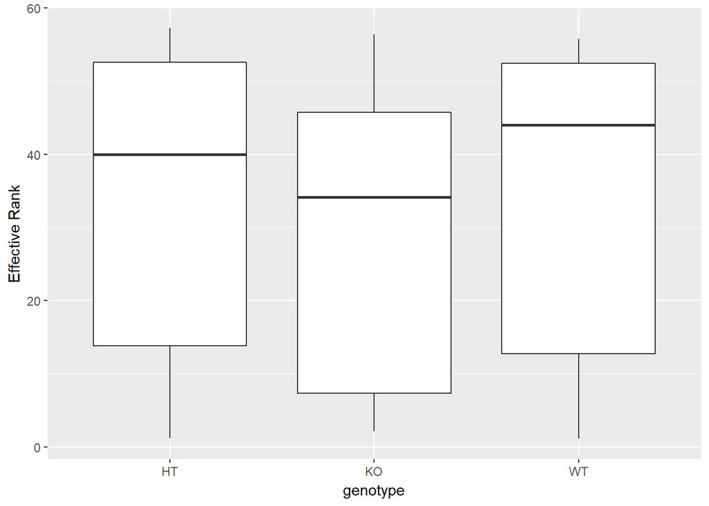

```r
ggplot(data = subset(df, is.finite(effRankCov))) +
  geom_boxplot(mapping = aes(genotype, effRankCov)) +
  ylab('Effective Rank')
```

- Although not significant, effective rank seems to be picking up some differences compared to spike and burst statistics
- looking at the 2309 and 1209 combined, it seems that there is some sigmoidal pattern of the effective rank, but the phase (eg. peak time) of that pattern is different between genotypes

# Moving forward

## Data selection

- I have created a [spreadsheet](https://docs.google.com/spreadsheets/d/1V1AB-rHq4vqZaLUIMfAs3baUr0GWPEhUrT0Ih0vyqAw/edit#gid=1756339059) to record down which files we are not going to include in our analyses
- Once we have that sorted I can run through the analyses again

## Data analyses

- network burst detection
- there are only a few appropriate methods I found for this, the most promising one is [Valkki et al 2017](https://www.frontiersin.org/articles/10.3389/fncom.2017.00040/full)
- I contacted the corresponding author of this paper and he says he will email his student to see if she can make the code share-able
- Another way is to use Maneull’s method, but I think we need to email him to clarify what is done as I can’t recreate it just by reading his paper
- calculating similar metrics within burst (effective rank, regularity)
- I am also thinking of quantifying the distribution of spikes across electrodes within individual MEAs, as this is what we were qualitatively trying to do by looking at the heatmaps and spike count distributions
- One way is to do normality (or other probability distribution) tests, eg. KS or SW tests
- it may be interesting to see if there is any relationship between this and effective rank
- I am thinking of calculating more measures that characterise the “controllability” of the system, particular in [Gu et al 2015](https://www.nature.com/articles/ncomms9414)
- but this will require creating a linear model of the network and this may be non-trivial, I am asking Guillaume about it.
- try the feature matrix on machine learning workflow just to make sure it works first